# Solution7

```python
%load_ext autoreload
%autoreload 2
```

```python
import os
import random
import math
import shutil
from tqdm import tqdm
import numpy as np
import matplotlib.pyplot as plt
from torch.utils.tensorboard import SummaryWriter

# torch
import torch
import torch.nn as nn
import torch.nn.functional as F
from torch.utils.data import DataLoader
import torchvision
from torchvision import datasets, models, transforms
```

```python
device = torch.device("cuda" if torch.cuda.is_available() else "cpu")
print(torch.cuda.is_available())
```

```
True
```

```python
BASE_LOG_DIR = os.path.join(os.getcwd(), "tboard_logs")

os.makedirs(BASE_LOG_DIR, exist_ok=True)
```

# Assignment 7

1. "Action Recognition" on the KTH-Actions dataset (same as from Assignment 3)
   - Use same settings as in that assignment
   - Already downloaded in `/home/nfs/inf6/data/datasets/kth_actions`
   - Use spatial dimensionality of frames of 64x64
   - Split videos into subsequences of e.g. 10 frames. Treat each of these subsequences as independent.
   - Feel free to use augmentations (temporal and/or spatial)
2. Train a transformer for 'Action Recongition'
   - Break each image into patches. You can decide on the pathc size
   - Jointly process all patches from the sequence with your transformer
   - Output a class prediction
3. Evaluate your Transformer module:
   - Compare at least 2 different patch sizes
   - Compare with the performance of your RNN models from Assignment 3 (no need to retrain them)

```python
DATA_FOLDER = '/home/nfs/inf6/data/datasets/kth_actions/raw'
```

```python
from KTHDataset import KTHDataset

KTH_CLASSES = ['boxing', 'handclapping', 'handwaving', 'jogging', 'running', 'walking']

train_dataset = KTHDataset(root_dir=DATA_FOLDER, train=True)
test_dataset = KTHDataset(root_dir=DATA_FOLDER, train=False)
```

```python
train_loader = DataLoader(train_dataset, batch_size=8, shuffle=True, num_workers=2)
test_loader = DataLoader(test_dataset, batch_size=8, shuffle=False, num_workers=2)
```

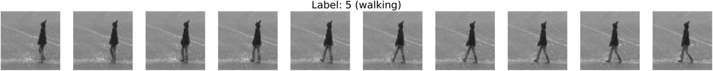

```python
frames, label = train_dataset[227]

num_frames = frames.shape[0]
fig, axes = plt.subplots(1, num_frames, figsize=(num_frames * 10, 10))

for i in range(num_frames):
    frame = frames[i]  #[3, 64, 64]
    frame_np = frame.permute(1, 2, 0).numpy()
    axes[i].imshow(frame_np)
    axes[i].axis('off')
fig.suptitle(f"Label: {label} ({KTH_CLASSES[label]})", fontsize=100)
plt.tight_layout()
plt.show()
```

```python
from models.TransformerBlock import TransformerBlock
from utils import count_model_params

tf_block = TransformerBlock(
        token_dim=128,
        attn_dim=128,
        num_heads=4,
        mlp_size=512
    ).to(device)

print(f"Transformer-Block has {count_model_params(tf_block)} parameters")
tf_block
```

```
Transformer-Block has 197760 parameters
```

```
TransformerBlock(
  (ln_att): LayerNorm((128,), eps=1e-06, elementwise_affine=True)
  (attn): MultiHeadSelfAttention(
    (q): Linear(in_features=128, out_features=128, bias=False)
    (k): Linear(in_features=128, out_features=128, bias=False)
    (v): Linear(in_features=128, out_features=128, bias=False)
    (out_proj): Linear(in_features=128, out_features=128, bias=False)
  )
  (ln_mlp): LayerNorm((128,), eps=1e-06, elementwise_affine=True)
  (mlp): MLP(
    (mlp): Sequential(
      (0): Linear(in_features=128, out_features=512, bias=True)
      (1): GELU(approximate='none')
      (2): Linear(in_features=512, out_features=128, bias=True)
    )
  )
)
```

```python
tokens = torch.rand((4, 16, 128), device=device)
out = tf_block(tokens)
attn_map = tf_block.get_attention_masks()

print(f"Input Shape: {tokens.shape}")
print(f"Output Shape: {out.shape}")
print(f"Attn. Map Shape: {attn_map.shape}")
```

```
Input Shape: torch.Size([4, 16, 128])
Output Shape: torch.Size([4, 16, 128])
Attn. Map Shape: torch.Size([4, 4, 16, 16])
```

```python
from models.Patchifier import Patchifier

PATCH_SIZE=16
patchifier = Patchifier(PATCH_SIZE)
```

```python
img, _ = next(iter(test_loader))
patch_data = patchifier(img)
```

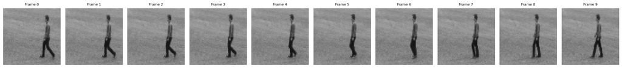

```python
BATCH_IDX = 2
video = img[BATCH_IDX]  # shape: [T, C, H, W]
T = video.shape[0]

fig, axes = plt.subplots(1, T, figsize=(T * 2, 2.5))

for t in range(T):
    frame = video[t]  # [C, H, W]
    frame_np = frame.permute(1, 2, 0).numpy()  # [H, W, C]

    axes[t].imshow(frame_np)
    axes[t].axis("off")
    axes[t].set_title(f"Frame {t}", fontsize=8)

plt.tight_layout()
plt.show()
```

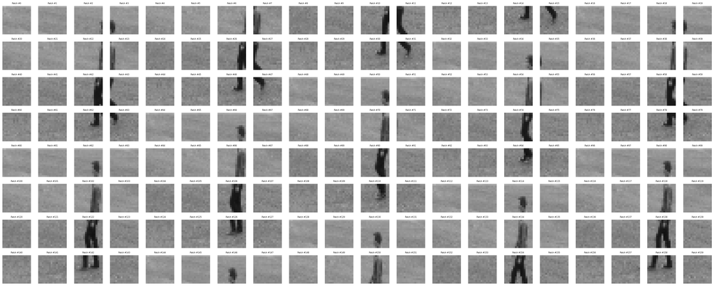

```python
num_patches_to_show = 10 * (64 // PATCH_SIZE) * (64 // PATCH_SIZE)
ncols = 20
nrows = num_patches_to_show // ncols

fig, axes = plt.subplots(nrows, ncols, figsize=(ncols * 1.5, nrows * 1.5))

for i in range(num_patches_to_show):
    row = i // ncols
    col = i % ncols
    ax = axes[row, col]

    cur_patch = patch_data[BATCH_IDX, i].reshape(3, PATCH_SIZE, PATCH_SIZE)
    patch_np = cur_patch.permute(1, 2, 0).numpy()

    ax.imshow(patch_np)
    ax.axis("off")
    ax.set_title(f"Patch #{i}", fontsize=6)

plt.tight_layout()
plt.show()
```

```python
from models.PositionalEncoding import PositionalEncoding

pe = PositionalEncoding(d_model=256, max_len=10 * (64 // PATCH_SIZE) * (64 // PATCH_SIZE) + 1)
```

```python
def train_epoch(model, train_loader, optimizer, criterion, epoch, device):
    """ Training a model for one epoch """

    loss_list = []
    for i, (images, labels) in enumerate(tqdm(train_loader)):
        images = images.to(device)
        labels = labels.to(device)

        # Clear gradients w.r.t. parameters
        optimizer.zero_grad()

        # Forward pass to get output/logits
        outputs = model(images)

        # Calculate Loss: softmax --> cross entropy loss
        loss = criterion(outputs, labels)
        loss_list.append(loss.item())

        # Getting gradients w.r.t. parameters
        loss.backward()

        # Updating parameters
        optimizer.step()

    mean_loss = np.mean(loss_list)
    return mean_loss, loss_list


@torch.no_grad()
def eval_model(model, eval_loader, criterion, device):
    """ Evaluating the model for either validation or test """
    correct = 0
    total = 0
    loss_list = []

    for images, labels in eval_loader:
        images = images.to(device)
        labels = labels.to(device)

        # Forward pass only to get logits/output
        outputs = model(images)

        loss = criterion(outputs, labels)
        loss_list.append(loss.item())

        # Get predictions from the maximum value
        preds = torch.argmax(outputs, dim=1)
        correct += len( torch.where(preds==labels)[0] )
        total += len(labels)

    # Total correct predictions and loss
    accuracy = correct / total * 100
    loss = np.mean(loss_list)

    return accuracy, loss


def train_model(model, optimizer, scheduler, criterion, train_loader, valid_loader, num_epochs, tboard=None, start_epoch=0):
    """ Training a model for a given number of epochs"""

    train_loss = []
    val_loss =  []
    loss_iters = []
    valid_acc = []

    for epoch in range(num_epochs):
        print(f"Started Epoch {epoch+1}/{num_epochs}...")

        # validation epoch
        print("  --> Running valdiation epoch")
        model.eval()  # important for dropout and batch norms
        accuracy, loss = eval_model(
                    model=model, eval_loader=valid_loader,
                    criterion=criterion, device=device
            )
        valid_acc.append(accuracy)
        val_loss.append(loss)
        tboard.add_scalar(f'Accuracy/Valid', accuracy, global_step=epoch+start_epoch)
        tboard.add_scalar(f'Loss/Valid', loss, global_step=epoch+start_epoch)

        # training epoch
        print("  --> Running train epoch")
        model.train()  # important for dropout and batch norms
        mean_loss, cur_loss_iters = train_epoch(
                model=model, train_loader=train_loader, optimizer=optimizer,
                criterion=criterion, epoch=epoch, device=device
            )
        scheduler.step()
        train_loss.append(mean_loss)
        tboard.add_scalar(f'Loss/Train', mean_loss, global_step=epoch+start_epoch)

        loss_iters = loss_iters + cur_loss_iters

        print(f"Epoch {epoch+1}/{num_epochs}")
        print(f"    Train loss: {round(mean_loss, 5)}")
        print(f"    Valid loss: {round(loss, 5)}")
        print(f"    Valid Accuracy: {accuracy}%")
        print("\n")

    print(f"Training completed")
    return train_loss, val_loss, loss_iters, valid_acc
```

```python
from models.ViT import ViT

vit = ViT(
        patch_size=PATCH_SIZE,
        token_dim=256,
        max_len=10 * (64 // PATCH_SIZE) * (64 // PATCH_SIZE) + 1,
        attn_dim=128,
        num_heads=4,
        mlp_size=512,
        num_tf_layers=4,
        num_classes=len(KTH_CLASSES)
    ).to(device)

# classification loss function
criterion = nn.CrossEntropyLoss()

# Observe that all parameters are being optimized
optimizer = torch.optim.Adam(vit.parameters(), lr=3e-4)

# Decay LR by a factor of 3 every 5 epochs
scheduler = torch.optim.lr_scheduler.StepLR(optimizer, step_size=10, gamma=1/3)

TBOARD_LOGS = os.path.join(os.getcwd(), "tboard_logs", "ViT_patch16")
if not os.path.exists(TBOARD_LOGS):
    os.makedirs(TBOARD_LOGS)

shutil.rmtree(TBOARD_LOGS)
writer = SummaryWriter(TBOARD_LOGS)

train_loss, val_loss, loss_iters, valid_acc = train_model(
        model=vit,
        optimizer=optimizer,
        scheduler=scheduler,
        criterion=criterion,
        train_loader=train_loader,
        valid_loader=test_loader,
        num_epochs=30,
        tboard=writer
    )
```

```
Started Epoch 1/30...
  --> Running valdiation epoch
  --> Running train epoch
```

```
    Train loss: 1.9673
    Valid loss: 1.87153
    Valid Accuracy: 15.833333333333332%


Started Epoch 2/30...
  --> Running valdiation epoch
```

```
  --> Running train epoch
```

```
    Train loss: 1.57543
    Valid loss: 1.66004
    Valid Accuracy: 33.33333333333333%


Started Epoch 3/30...
  --> Running valdiation epoch
```

```
  --> Running train epoch
```

```
    Train loss: 1.37157
    Valid loss: 1.4942
    Valid Accuracy: 33.33333333333333%


Started Epoch 4/30...
  --> Running valdiation epoch
```

```
  --> Running train epoch
```

```
    Train loss: 1.10521
    Valid loss: 1.08919
    Valid Accuracy: 51.66666666666667%


Started Epoch 5/30...
  --> Running valdiation epoch
```

```
  --> Running train epoch
```

```
    Train loss: 0.84158
    Valid loss: 0.91786
    Valid Accuracy: 62.5%


Started Epoch 6/30...
  --> Running valdiation epoch
```

```
  --> Running train epoch
```

```
    Train loss: 0.72801
    Valid loss: 0.76529
    Valid Accuracy: 70.83333333333334%


Started Epoch 7/30...
  --> Running valdiation epoch
```

```
  --> Running train epoch
```

```
    Train loss: 0.52498
    Valid loss: 0.55845
    Valid Accuracy: 84.16666666666667%


Started Epoch 8/30...
  --> Running valdiation epoch
```

```
  --> Running train epoch
```

```
    Train loss: 0.46743
    Valid loss: 0.75369
    Valid Accuracy: 71.66666666666667%


Started Epoch 9/30...
  --> Running valdiation epoch
```

```
  --> Running train epoch
```

```
    Train loss: 0.5609
    Valid loss: 0.58824
    Valid Accuracy: 80.0%


Started Epoch 10/30...
  --> Running valdiation epoch
```

```
  --> Running train epoch
```

```
    Train loss: 0.28839
    Valid loss: 0.5521
    Valid Accuracy: 80.0%


Started Epoch 11/30...
  --> Running valdiation epoch
```

```
  --> Running train epoch
```

```
    Train loss: 0.07859
    Valid loss: 0.41832
    Valid Accuracy: 89.16666666666667%


Started Epoch 12/30...
  --> Running valdiation epoch
```

```
  --> Running train epoch
```

```
    Train loss: 0.03251
    Valid loss: 0.31704
    Valid Accuracy: 92.5%


Started Epoch 13/30...
  --> Running valdiation epoch
```

```
  --> Running train epoch
```

```
    Train loss: 0.01806
    Valid loss: 0.31221
    Valid Accuracy: 93.33333333333333%


Started Epoch 14/30...
  --> Running valdiation epoch
```

```
  --> Running train epoch
```

```
    Train loss: 0.01226
    Valid loss: 0.31337
    Valid Accuracy: 93.33333333333333%


Started Epoch 15/30...
  --> Running valdiation epoch
```

```
  --> Running train epoch
```

```
    Train loss: 0.00906
    Valid loss: 0.31715
    Valid Accuracy: 93.33333333333333%


Started Epoch 16/30...
  --> Running valdiation epoch
  --> Running train epoch
```

```
    Train loss: 0.00681
    Valid loss: 0.32074
    Valid Accuracy: 93.33333333333333%


Started Epoch 17/30...
  --> Running valdiation epoch
```

```
  --> Running train epoch
```

```
    Train loss: 0.00553
    Valid loss: 0.32343
    Valid Accuracy: 92.5%


Started Epoch 18/30...
  --> Running valdiation epoch
```

```
  --> Running train epoch
```

```
    Train loss: 0.00449
    Valid loss: 0.32972
    Valid Accuracy: 92.5%


Started Epoch 19/30...
  --> Running valdiation epoch
```

```
  --> Running train epoch
```

```
    Train loss: 0.00375
    Valid loss: 0.33162
    Valid Accuracy: 92.5%


Started Epoch 20/30...
  --> Running valdiation epoch
```

```
  --> Running train epoch
```

```
    Train loss: 0.00314
    Valid loss: 0.33786
    Valid Accuracy: 92.5%


Started Epoch 21/30...
  --> Running valdiation epoch
```

```
  --> Running train epoch
```

```
    Train loss: 0.00273
    Valid loss: 0.34207
    Valid Accuracy: 92.5%


Started Epoch 22/30...
  --> Running valdiation epoch
```

```
  --> Running train epoch
```

```
    Train loss: 0.0026
    Valid loss: 0.34324
    Valid Accuracy: 92.5%


Started Epoch 23/30...
  --> Running valdiation epoch
```

```
  --> Running train epoch
```

```
    Train loss: 0.00247
    Valid loss: 0.34471
    Valid Accuracy: 92.5%


Started Epoch 24/30...
  --> Running valdiation epoch
```

```
  --> Running train epoch
```

```
    Train loss: 0.00236
    Valid loss: 0.34596
    Valid Accuracy: 92.5%


Started Epoch 25/30...
  --> Running valdiation epoch
```

```
  --> Running train epoch
```

```
    Train loss: 0.00225
    Valid loss: 0.34754
    Valid Accuracy: 92.5%


Started Epoch 26/30...
  --> Running valdiation epoch
```

```
  --> Running train epoch
```

```
    Train loss: 0.00213
    Valid loss: 0.34886
    Valid Accuracy: 92.5%


Started Epoch 27/30...
  --> Running valdiation epoch
```

```
  --> Running train epoch
```

```
    Train loss: 0.00203
    Valid loss: 0.35041
    Valid Accuracy: 92.5%


Started Epoch 28/30...
  --> Running valdiation epoch
```

```
  --> Running train epoch
```

```
    Train loss: 0.00193
    Valid loss: 0.35158
    Valid Accuracy: 92.5%


Started Epoch 29/30...
  --> Running valdiation epoch
```

```
  --> Running train epoch
```

```
    Train loss: 0.00184
    Valid loss: 0.35324
    Valid Accuracy: 92.5%


Started Epoch 30/30...
  --> Running valdiation epoch
```

```
  --> Running train epoch
```

```
    Train loss: 0.00175
    Valid loss: 0.35443
    Valid Accuracy: 92.5%


Training completed
```

```python
PATCH_SIZE=8

vit = ViT(
        patch_size=PATCH_SIZE,
        token_dim=256,
        max_len=10 * (64 // PATCH_SIZE) * (64 // PATCH_SIZE) + 1,
        attn_dim=128,
        num_heads=4,
        mlp_size=512,
        num_tf_layers=4,
        num_classes=len(KTH_CLASSES)
    ).to(device)

# classification loss function
criterion = nn.CrossEntropyLoss()

# Observe that all parameters are being optimized
optimizer = torch.optim.Adam(vit.parameters(), lr=3e-4)

# Decay LR by a factor of 3 every 5 epochs
scheduler = torch.optim.lr_scheduler.StepLR(optimizer, step_size=10, gamma=1/3)

TBOARD_LOGS = os.path.join(os.getcwd(), "tboard_logs", "ViT_patch8")
if not os.path.exists(TBOARD_LOGS):
    os.makedirs(TBOARD_LOGS)

shutil.rmtree(TBOARD_LOGS)
writer = SummaryWriter(TBOARD_LOGS)

train_loss, val_loss, loss_iters, valid_acc = train_model(
        model=vit,
        optimizer=optimizer,
        scheduler=scheduler,
        criterion=criterion,
        train_loader=train_loader,
        valid_loader=test_loader,
        num_epochs=30,
        tboard=writer
    )
```

```
Started Epoch 1/30...
  --> Running valdiation epoch
  --> Running train epoch
```

```
    Train loss: 2.00516
    Valid loss: 1.94636
    Valid Accuracy: 16.666666666666664%


Started Epoch 2/30...
  --> Running valdiation epoch
```

```
  --> Running train epoch
```

```
    Train loss: 1.84383
    Valid loss: 1.80097
    Valid Accuracy: 19.166666666666668%


Started Epoch 3/30...
  --> Running valdiation epoch
```

```
  --> Running train epoch
```

```
    Train loss: 1.79588
    Valid loss: 1.80211
    Valid Accuracy: 24.166666666666668%


Started Epoch 4/30...
  --> Running valdiation epoch
```

```
  --> Running train epoch
```

```
    Train loss: 1.62468
    Valid loss: 1.68964
    Valid Accuracy: 26.666666666666668%


Started Epoch 5/30...
  --> Running valdiation epoch
```

```
  --> Running train epoch
```

```
    Train loss: 1.49201
    Valid loss: 1.56808
    Valid Accuracy: 34.166666666666664%


Started Epoch 6/30...
  --> Running valdiation epoch
```

```
  --> Running train epoch
```

```
    Train loss: 1.22908
    Valid loss: 1.26522
    Valid Accuracy: 45.0%


Started Epoch 7/30...
  --> Running valdiation epoch
```

```
  --> Running train epoch
```

```
    Train loss: 1.14057
    Valid loss: 1.22048
    Valid Accuracy: 45.0%


Started Epoch 8/30...
  --> Running valdiation epoch
```

```
  --> Running train epoch
```

```
    Train loss: 0.9371
    Valid loss: 1.09675
    Valid Accuracy: 53.333333333333336%


Started Epoch 9/30...
  --> Running valdiation epoch
```

```
  --> Running train epoch
```

```
    Train loss: 0.79412
    Valid loss: 0.91783
    Valid Accuracy: 60.83333333333333%


Started Epoch 10/30...
  --> Running valdiation epoch
```

```
  --> Running train epoch
```

```
    Train loss: 0.74794
    Valid loss: 1.05054
    Valid Accuracy: 62.5%


Started Epoch 11/30...
  --> Running valdiation epoch
```

```
  --> Running train epoch
```

```
    Train loss: 0.40966
    Valid loss: 0.72734
    Valid Accuracy: 75.83333333333333%


Started Epoch 12/30...
  --> Running valdiation epoch
```

```
  --> Running train epoch
```

```
    Train loss: 0.22188
    Valid loss: 0.50697
    Valid Accuracy: 85.83333333333333%


Started Epoch 13/30...
  --> Running valdiation epoch
```

```
  --> Running train epoch
```

```
    Train loss: 0.14818
    Valid loss: 0.46464
    Valid Accuracy: 87.5%


Started Epoch 14/30...
  --> Running valdiation epoch
```

```
  --> Running train epoch
```

```
    Train loss: 0.07596
    Valid loss: 0.46169
    Valid Accuracy: 89.16666666666667%


Started Epoch 15/30...
  --> Running valdiation epoch
```

```
  --> Running train epoch
```

```
    Train loss: 0.03644
    Valid loss: 0.46888
    Valid Accuracy: 90.0%


Started Epoch 16/30...
  --> Running valdiation epoch
```

```
  --> Running train epoch
```

```
    Train loss: 0.01749
    Valid loss: 0.47322
    Valid Accuracy: 90.83333333333333%


Started Epoch 17/30...
  --> Running valdiation epoch
```

```
  --> Running train epoch
```

```
    Train loss: 0.01099
    Valid loss: 0.52543
    Valid Accuracy: 90.0%


Started Epoch 18/30...
  --> Running valdiation epoch
```

```
  --> Running train epoch
```

```
    Train loss: 0.00759
    Valid loss: 0.5363
    Valid Accuracy: 90.83333333333333%


Started Epoch 19/30...
  --> Running valdiation epoch
```

```
  --> Running train epoch
```

```
    Train loss: 0.00518
    Valid loss: 0.55469
    Valid Accuracy: 90.83333333333333%


Started Epoch 20/30...
  --> Running valdiation epoch
```

```
  --> Running train epoch
```

```
    Train loss: 0.00402
    Valid loss: 0.57408
    Valid Accuracy: 90.83333333333333%


Started Epoch 21/30...
  --> Running valdiation epoch
```

```
  --> Running train epoch
```

```
    Train loss: 0.00334
    Valid loss: 0.59639
    Valid Accuracy: 90.83333333333333%


Started Epoch 22/30...
  --> Running valdiation epoch
```

```
  --> Running train epoch
```

```
    Train loss: 0.00307
    Valid loss: 0.59571
    Valid Accuracy: 90.83333333333333%


Started Epoch 23/30...
  --> Running valdiation epoch
```

```
  --> Running train epoch
```

```
    Train loss: 0.00289
    Valid loss: 0.59846
    Valid Accuracy: 90.83333333333333%


Started Epoch 24/30...
  --> Running valdiation epoch
```

```
  --> Running train epoch
```

```
    Train loss: 0.00271
    Valid loss: 0.60154
    Valid Accuracy: 90.83333333333333%


Started Epoch 25/30...
  --> Running valdiation epoch
```

```
  --> Running train epoch
```

```
    Train loss: 0.00254
    Valid loss: 0.61013
    Valid Accuracy: 90.83333333333333%


Started Epoch 26/30...
  --> Running valdiation epoch
```

```
  --> Running train epoch
```

```
    Train loss: 0.00238
    Valid loss: 0.61219
    Valid Accuracy: 90.83333333333333%


Started Epoch 27/30...
  --> Running valdiation epoch
```

```
  --> Running train epoch
```

```
    Train loss: 0.00223
    Valid loss: 0.61694
    Valid Accuracy: 90.83333333333333%


Started Epoch 28/30...
  --> Running valdiation epoch
```

```
  --> Running train epoch
```

```
    Train loss: 0.00211
    Valid loss: 0.6219
    Valid Accuracy: 90.83333333333333%


Started Epoch 29/30...
  --> Running valdiation epoch
```

```
  --> Running train epoch
```

```
    Train loss: 0.00199
    Valid loss: 0.62611
    Valid Accuracy: 90.83333333333333%


Started Epoch 30/30...
  --> Running valdiation epoch
```

```
  --> Running train epoch
```

```
    Train loss: 0.00187
    Valid loss: 0.63121
    Valid Accuracy: 90.83333333333333%


Training completed
```

```python
PATCH_SIZE=32
vit = ViT(
        patch_size=PATCH_SIZE,
        token_dim=256,
        max_len=10 * (64 // PATCH_SIZE) * (64 // PATCH_SIZE) + 1,
        attn_dim=128,
        num_heads=4,
        mlp_size=512,
        num_tf_layers=4,
        num_classes=len(KTH_CLASSES)
    ).to(device)

# classification loss function
criterion = nn.CrossEntropyLoss()

# Observe that all parameters are being optimized
optimizer = torch.optim.Adam(vit.parameters(), lr=3e-4)

# Decay LR by a factor of 3 every 5 epochs
scheduler = torch.optim.lr_scheduler.StepLR(optimizer, step_size=10, gamma=1/3)

TBOARD_LOGS = os.path.join(os.getcwd(), "tboard_logs", "ViT_patch32")
if not os.path.exists(TBOARD_LOGS):
    os.makedirs(TBOARD_LOGS)

shutil.rmtree(TBOARD_LOGS)
writer = SummaryWriter(TBOARD_LOGS)

train_loss, val_loss, loss_iters, valid_acc = train_model(
        model=vit,
        optimizer=optimizer,
        scheduler=scheduler,
        criterion=criterion,
        train_loader=train_loader,
        valid_loader=test_loader,
        num_epochs=30,
        tboard=writer
    )
```

```
Started Epoch 1/30...
  --> Running valdiation epoch
  --> Running train epoch
```

```
    Train loss: 1.7829
    Valid loss: 1.85831
    Valid Accuracy: 16.666666666666664%


Started Epoch 2/30...
  --> Running valdiation epoch
```

```
  --> Running train epoch
```

```
    Train loss: 1.36797
    Valid loss: 1.51801
    Valid Accuracy: 40.833333333333336%


Started Epoch 3/30...
  --> Running valdiation epoch
```

```
  --> Running train epoch
```

```
    Train loss: 1.17399
    Valid loss: 1.16679
    Valid Accuracy: 51.66666666666667%


Started Epoch 4/30...
  --> Running valdiation epoch
```

```
  --> Running train epoch
```

```
    Train loss: 0.85429
    Valid loss: 1.03415
    Valid Accuracy: 55.00000000000001%


Started Epoch 5/30...
  --> Running valdiation epoch
```

```
  --> Running train epoch
```

```
    Train loss: 0.66047
    Valid loss: 0.64243
    Valid Accuracy: 79.16666666666666%


Started Epoch 6/30...
  --> Running valdiation epoch
```

```
  --> Running train epoch
```

```
    Train loss: 0.56284
    Valid loss: 0.62381
    Valid Accuracy: 75.83333333333333%


Started Epoch 7/30...
  --> Running valdiation epoch
```

```
  --> Running train epoch
```

```
    Train loss: 0.39137
    Valid loss: 0.53372
    Valid Accuracy: 81.66666666666667%


Started Epoch 8/30...
  --> Running valdiation epoch
```

```
  --> Running train epoch
```

```
    Train loss: 0.28242
    Valid loss: 0.44242
    Valid Accuracy: 89.16666666666667%


Started Epoch 9/30...
  --> Running valdiation epoch
```

```
  --> Running train epoch
```

```
    Train loss: 0.40015
    Valid loss: 0.47568
    Valid Accuracy: 86.66666666666667%


Started Epoch 10/30...
  --> Running valdiation epoch
```

```
  --> Running train epoch
```

```
    Train loss: 0.187
    Valid loss: 0.44465
    Valid Accuracy: 89.16666666666667%


Started Epoch 11/30...
  --> Running valdiation epoch
```

```
  --> Running train epoch
```

```
    Train loss: 0.05768
    Valid loss: 0.40908
    Valid Accuracy: 90.0%


Started Epoch 12/30...
  --> Running valdiation epoch
```

```
  --> Running train epoch
```

```
    Train loss: 0.02415
    Valid loss: 0.38884
    Valid Accuracy: 92.5%


Started Epoch 13/30...
  --> Running valdiation epoch
```

```
  --> Running train epoch
```

```
    Train loss: 0.01567
    Valid loss: 0.39639
    Valid Accuracy: 91.66666666666666%


Started Epoch 14/30...
  --> Running valdiation epoch
```

```
  --> Running train epoch
```

```
    Train loss: 0.01132
    Valid loss: 0.41096
    Valid Accuracy: 91.66666666666666%


Started Epoch 15/30...
  --> Running valdiation epoch
```

```
  --> Running train epoch
```

```
    Train loss: 0.0079
    Valid loss: 0.42063
    Valid Accuracy: 91.66666666666666%


Started Epoch 16/30...
  --> Running valdiation epoch
```

```
  --> Running train epoch
```

```
    Train loss: 0.00704
    Valid loss: 0.41843
    Valid Accuracy: 90.83333333333333%


Started Epoch 17/30...
  --> Running valdiation epoch
```

```
  --> Running train epoch
```

```
    Train loss: 0.00551
    Valid loss: 0.43669
    Valid Accuracy: 91.66666666666666%


Started Epoch 18/30...
  --> Running valdiation epoch
```

```
  --> Running train epoch
```

```
    Train loss: 0.0043
    Valid loss: 0.44366
    Valid Accuracy: 91.66666666666666%


Started Epoch 19/30...
  --> Running valdiation epoch
```

```
  --> Running train epoch
```

```
    Train loss: 0.00372
    Valid loss: 0.44429
    Valid Accuracy: 91.66666666666666%


Started Epoch 20/30...
  --> Running valdiation epoch
```

```
  --> Running train epoch
```

```
    Train loss: 0.00303
    Valid loss: 0.45472
    Valid Accuracy: 91.66666666666666%


Started Epoch 21/30...
  --> Running valdiation epoch
```

```
  --> Running train epoch
```

```
    Train loss: 0.00269
    Valid loss: 0.45989
    Valid Accuracy: 91.66666666666666%


Started Epoch 22/30...
  --> Running valdiation epoch
```

```
  --> Running train epoch
```

```
    Train loss: 0.00255
    Valid loss: 0.46324
    Valid Accuracy: 91.66666666666666%


Started Epoch 23/30...
  --> Running valdiation epoch
```

```
  --> Running train epoch
```

```
    Train loss: 0.00246
    Valid loss: 0.46603
    Valid Accuracy: 91.66666666666666%


Started Epoch 24/30...
  --> Running valdiation epoch
```

```
  --> Running train epoch
```

```
    Train loss: 0.00231
    Valid loss: 0.4683
    Valid Accuracy: 91.66666666666666%


Started Epoch 25/30...
  --> Running valdiation epoch
```

```
  --> Running train epoch
```

```
    Train loss: 0.00222
    Valid loss: 0.47164
    Valid Accuracy: 91.66666666666666%


Started Epoch 26/30...
  --> Running valdiation epoch
```

```
  --> Running train epoch
```

```
    Train loss: 0.00212
    Valid loss: 0.47342
    Valid Accuracy: 91.66666666666666%


Started Epoch 27/30...
  --> Running valdiation epoch
```

```
  --> Running train epoch
```

```
    Train loss: 0.00201
    Valid loss: 0.47551
    Valid Accuracy: 91.66666666666666%


Started Epoch 28/30...
  --> Running valdiation epoch
```

```
  --> Running train epoch
```

```
    Train loss: 0.00192
    Valid loss: 0.47753
    Valid Accuracy: 91.66666666666666%


Started Epoch 29/30...
  --> Running valdiation epoch
```

```
  --> Running train epoch
```

```
    Train loss: 0.00184
    Valid loss: 0.47971
    Valid Accuracy: 91.66666666666666%


Started Epoch 30/30...
  --> Running valdiation epoch
```

```
  --> Running train epoch
```

```
    Train loss: 0.00175
    Valid loss: 0.48249
    Valid Accuracy: 91.66666666666666%


Training completed
```

```python
PATCH_SIZE=64
vit = ViT(
        patch_size=PATCH_SIZE,
        token_dim=256,
        max_len=10 * (64 // PATCH_SIZE) * (64 // PATCH_SIZE) + 1,
        attn_dim=128,
        num_heads=4,
        mlp_size=512,
        num_tf_layers=4,
        num_classes=len(KTH_CLASSES)
    ).to(device)

# classification loss function
criterion = nn.CrossEntropyLoss()

# Observe that all parameters are being optimized
optimizer = torch.optim.Adam(vit.parameters(), lr=3e-4)

# Decay LR by a factor of 3 every 5 epochs
scheduler = torch.optim.lr_scheduler.StepLR(optimizer, step_size=10, gamma=1/3)

TBOARD_LOGS = os.path.join(os.getcwd(), "tboard_logs", "ViT_patch64")
if not os.path.exists(TBOARD_LOGS):
    os.makedirs(TBOARD_LOGS)

shutil.rmtree(TBOARD_LOGS)
writer = SummaryWriter(TBOARD_LOGS)

train_loss, val_loss, loss_iters, valid_acc = train_model(
        model=vit,
        optimizer=optimizer,
        scheduler=scheduler,
        criterion=criterion,
        train_loader=train_loader,
        valid_loader=test_loader,
        num_epochs=30,
        tboard=writer
    )
```

```
Started Epoch 1/30...
  --> Running valdiation epoch
  --> Running train epoch
```

```
    Train loss: 1.75956
    Valid loss: 1.93851
    Valid Accuracy: 17.5%


Started Epoch 2/30...
  --> Running valdiation epoch
```

```
  --> Running train epoch
```

```
    Train loss: 1.27607
    Valid loss: 1.47555
    Valid Accuracy: 35.0%


Started Epoch 3/30...
  --> Running valdiation epoch
```

```
  --> Running train epoch
```

```
    Train loss: 1.08298
    Valid loss: 1.22984
    Valid Accuracy: 45.0%


Started Epoch 4/30...
  --> Running valdiation epoch
```

```
  --> Running train epoch
```

```
    Train loss: 0.91005
    Valid loss: 0.81945
    Valid Accuracy: 63.33333333333333%


Started Epoch 5/30...
  --> Running valdiation epoch
```

```
  --> Running train epoch
```

```
    Train loss: 0.79242
    Valid loss: 0.71984
    Valid Accuracy: 65.0%


Started Epoch 6/30...
  --> Running valdiation epoch
```

```
  --> Running train epoch
```

```
    Train loss: 0.68564
    Valid loss: 0.63064
    Valid Accuracy: 75.0%


Started Epoch 7/30...
  --> Running valdiation epoch
```

```
  --> Running train epoch
```

```
    Train loss: 0.52561
    Valid loss: 0.5926
    Valid Accuracy: 72.5%


Started Epoch 8/30...
  --> Running valdiation epoch
```

```
  --> Running train epoch
```

```
    Train loss: 0.56454
    Valid loss: 0.79395
    Valid Accuracy: 70.0%


Started Epoch 9/30...
  --> Running valdiation epoch
```

```
  --> Running train epoch
```

```
    Train loss: 0.36026
    Valid loss: 0.34853
    Valid Accuracy: 82.5%


Started Epoch 10/30...
  --> Running valdiation epoch
```

```
  --> Running train epoch
```

```
    Train loss: 0.33285
    Valid loss: 0.45251
    Valid Accuracy: 85.0%


Started Epoch 11/30...
  --> Running valdiation epoch
```

```
  --> Running train epoch
```

```
    Train loss: 0.19501
    Valid loss: 0.35143
    Valid Accuracy: 85.83333333333333%


Started Epoch 12/30...
  --> Running valdiation epoch
```

```
  --> Running train epoch
```

```
    Train loss: 0.10888
    Valid loss: 0.20716
    Valid Accuracy: 93.33333333333333%


Started Epoch 13/30...
  --> Running valdiation epoch
```

```
  --> Running train epoch
```

```
    Train loss: 0.06477
    Valid loss: 0.18306
    Valid Accuracy: 94.16666666666667%


Started Epoch 14/30...
  --> Running valdiation epoch
```

```
  --> Running train epoch
```

```
    Train loss: 0.06822
    Valid loss: 0.20524
    Valid Accuracy: 93.33333333333333%


Started Epoch 15/30...
  --> Running valdiation epoch
```

```
  --> Running train epoch
```

```
    Train loss: 0.0457
    Valid loss: 0.32067
    Valid Accuracy: 91.66666666666666%


Started Epoch 16/30...
  --> Running valdiation epoch
```

```
  --> Running train epoch
```

```
    Train loss: 0.02834
    Valid loss: 0.16338
    Valid Accuracy: 95.0%


Started Epoch 17/30...
  --> Running valdiation epoch
```

```
  --> Running train epoch
```

```
    Train loss: 0.03298
    Valid loss: 0.20848
    Valid Accuracy: 94.16666666666667%


Started Epoch 18/30...
  --> Running valdiation epoch
```

```
  --> Running train epoch
```

```
    Train loss: 0.05523
    Valid loss: 0.29634
    Valid Accuracy: 92.5%


Started Epoch 19/30...
  --> Running valdiation epoch
```

```
  --> Running train epoch
```

```
    Train loss: 0.06836
    Valid loss: 0.17596
    Valid Accuracy: 95.83333333333334%


Started Epoch 20/30...
  --> Running valdiation epoch
```

```
  --> Running train epoch
```

```
    Train loss: 0.03739
    Valid loss: 0.24936
    Valid Accuracy: 95.0%


Started Epoch 21/30...
  --> Running valdiation epoch
```

```
  --> Running train epoch
```

```
    Train loss: 0.01179
    Valid loss: 0.23104
    Valid Accuracy: 95.0%


Started Epoch 22/30...
  --> Running valdiation epoch
```

```
  --> Running train epoch
```

```
    Train loss: 0.008
    Valid loss: 0.21138
    Valid Accuracy: 95.0%


Started Epoch 23/30...
  --> Running valdiation epoch
```

```
  --> Running train epoch
```

```
    Train loss: 0.00678
    Valid loss: 0.20872
    Valid Accuracy: 95.0%


Started Epoch 24/30...
  --> Running valdiation epoch
```

```
  --> Running train epoch
```

```
    Train loss: 0.00595
    Valid loss: 0.20868
    Valid Accuracy: 95.0%


Started Epoch 25/30...
  --> Running valdiation epoch
```

```
  --> Running train epoch
```

```
    Train loss: 0.00528
    Valid loss: 0.20921
    Valid Accuracy: 95.0%


Started Epoch 26/30...
  --> Running valdiation epoch
```

```
  --> Running train epoch
```

```
    Train loss: 0.00473
    Valid loss: 0.21185
    Valid Accuracy: 95.0%


Started Epoch 27/30...
  --> Running valdiation epoch
```

```
  --> Running train epoch
```

```
    Train loss: 0.00427
    Valid loss: 0.21359
    Valid Accuracy: 95.0%


Started Epoch 28/30...
  --> Running valdiation epoch
```

```
  --> Running train epoch
```

```
    Train loss: 0.00398
    Valid loss: 0.21714
    Valid Accuracy: 95.0%


Started Epoch 29/30...
  --> Running valdiation epoch
```

```
  --> Running train epoch
```

```
    Train loss: 0.00353
    Valid loss: 0.21843
    Valid Accuracy: 95.0%


Started Epoch 30/30...
  --> Running valdiation epoch
```

```
  --> Running train epoch
```

```
    Train loss: 0.00322
    Valid loss: 0.22044
    Valid Accuracy: 95.0%


Training completed
```

- ViT_patch64 (where patch size equals the full image: 64×64) achieves the highest accuracy: 95%
- Then come ViT_patch16 and ViT_patch32 (around 91–92%)
- ViT_patch8 performs the worst (90.8%)

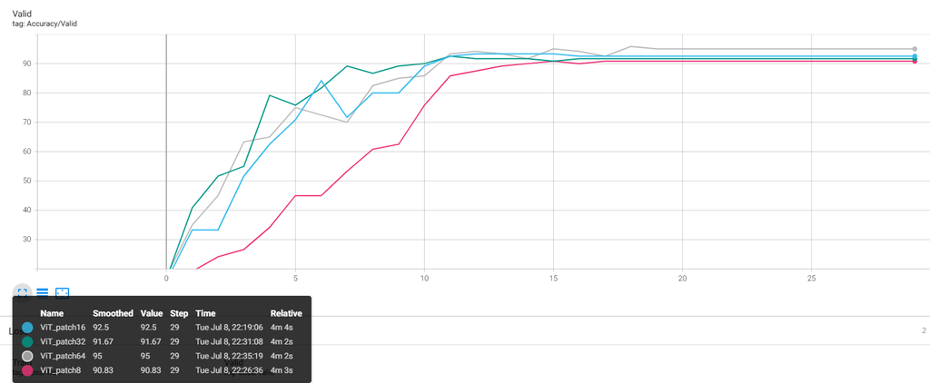

This might be due to the:

1. Larger patches mean fewer tokens and easier training, especially on small datasets.

   With patch64 model, each frame is just 1 token, so for 10 frames: [BOS] + 10 tokens = 11 total tokens

   patch16: 4×4 = 16 patches per frame → 10×16 + 1 = 161 tokens

   patch8: 8×8 = 64 patches per frame → 10×64 + 1 = 641 tokens
2. When using small patches, the bulk of them do not contain any details, which can cause the model to fixate on irrelevant textures or noise. Large patches capture global motion and shape, which is better in our case

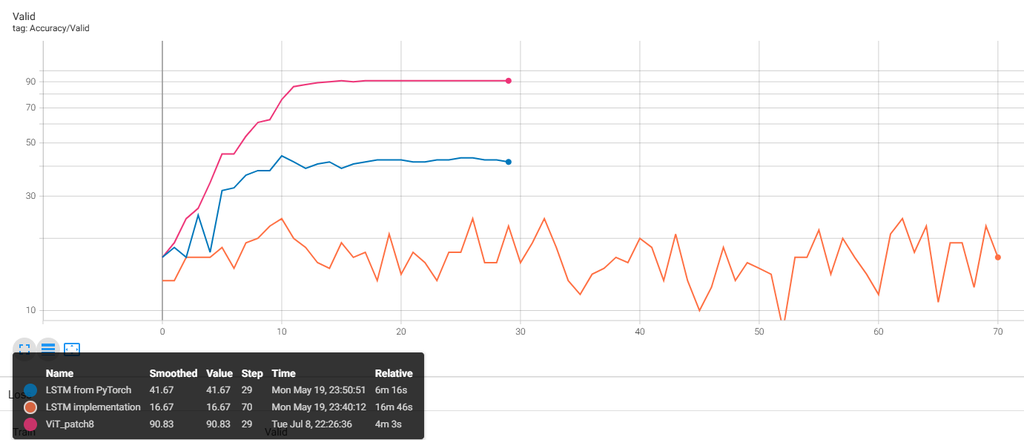

Vision Transformer (ViT) significantly outperforms LSTM (both implementations, inclusing PyTorch version) in both accuracy and stability for action recognition, effectively learning even with a small patch size.